# Travaux dirigés 1 - MAP201, thème équation différentielles

Le TP est à faire en python, où la réponse à chaque question est dans une cellule séparée. On veillera à écrire un code suffisamment clair pour être éventuellement réutilisé d'un exercice à l'autre. Ci-dessous, un code d'exemple fonctionnel qui rappelle quelques fonctions python élémentaires nécessaires à la création de tableaux et à l'affichage de courbes: n'hésitez pas à modifier ses paramètres pour faire des test et à piocher dedans.

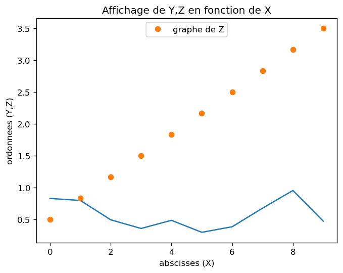

```python
import numpy as np #importe les outils de gestion des tableaux
import matplotlib.pyplot as plt #importe les outils d'affichages matplotlib
plt.rcParams['figure.dpi'] = 120 #reglage facultatif de résolution des figures
plt.rcParams['savefig.dpi'] = 240 #reglage facultatif de résolution des figures enregistrées

N=10#déclare une variable N initialisee sur la valeur 10
X=np.arange(N) #crée le tableau [0,1,2,3,4,5,....,N-1]. X[i]=i pour i=0,1,...,N-1
Y=np.random.random(N) #crée un tableau de N nombre aléatoires entre 0 et 1, numerotes de 0 a N-1
Z=np.linspace(0.5,3.5,N) #crée un tableau de N nombres qui subdivisisent l'intervalle [0.5,3.5] avec un écart régulier

plt.plot(X,Y) #Trace le graphe de Y en fonction de X, en rejoignant les points (X[i],Y[i]) pour i=0,..,N-1.
#Par defaut le graphe est represente en tracant les segments [(X[i],Y[i]),(X[i+1],Y[i+1])] pour i=0,1,..,N-2, cela peut etre changé.
plt.plot(X,Z,'o',label='graphe de Z') #Trace le graphe de Z en fonction de X, avec en plus une legende associee a ce graphe.
# L'argument 'o' permet de tracer seulement les points (X[i],Z[i]), sans les relier
plt.title("Affichage de Y,Z en fonction de X") #Donne un titre à la figure
plt.legend(loc='upper center') #localisation de l'affichage des legendes
plt.xlabel("abscisses (X)") #Nomme l'axe des abscisses
plt.ylabel("ordonnees (Y,Z)") #Nomme l'axe des ordonnees
plt.show() #affichage de la figure
```

## Exercice 1 - Etude de $x'(t)=f(x(t))$.

### 1)

Afficher, dans des fenêtres séparées, les graphes des fonctions ci-dessous sur l'intervalle indiqué.

- a) $f(x)=(1-x^2)x$ sur $[3/2,3/2]$.
- b) $f(x)=-\sin(x)$ sur $[-2\pi,2\pi]$.
- c) $f(x)=1-\cos(x)$ sur $[-2\pi,2\pi]$.
- d) $f(x)=1.5-\sin(x)$ sur $[-2\pi,2\pi]$.

Pour afficher le graphe d'une fonction $f$ sur un intervalle $[a,b]$, on construit les tableaux $$X=[x_0,x_1,x_2,..,x_N],\ Y=[f(x_0),f(x_1),..,f(x_N)]$$ où $a=x_0<x_1<x_2<..<x_N=b$ est une subdivision suffisament fine de l'intervalle $[a,b]$, et on trace $Y$ en fonction de $X$ (se réferer au code d'exemple). On affichera aussi sur le graphe l'axe des abscisses.

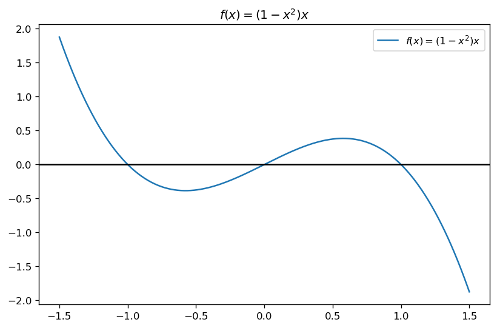

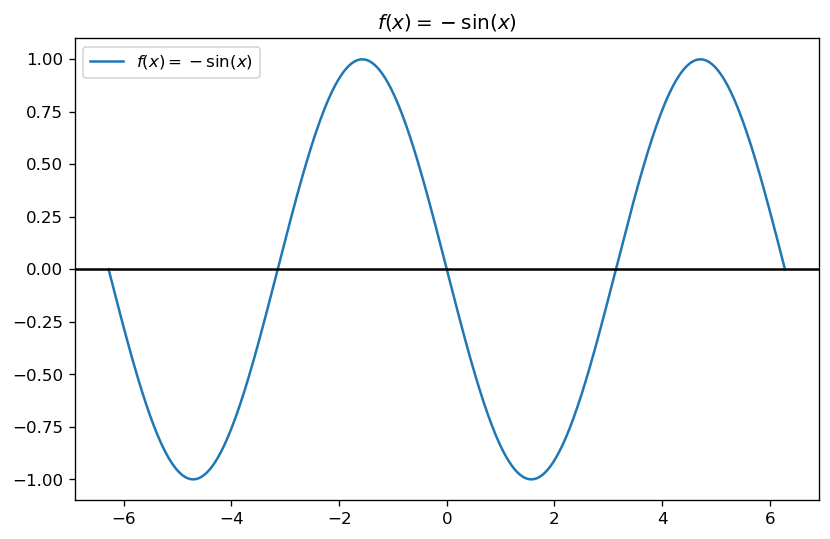

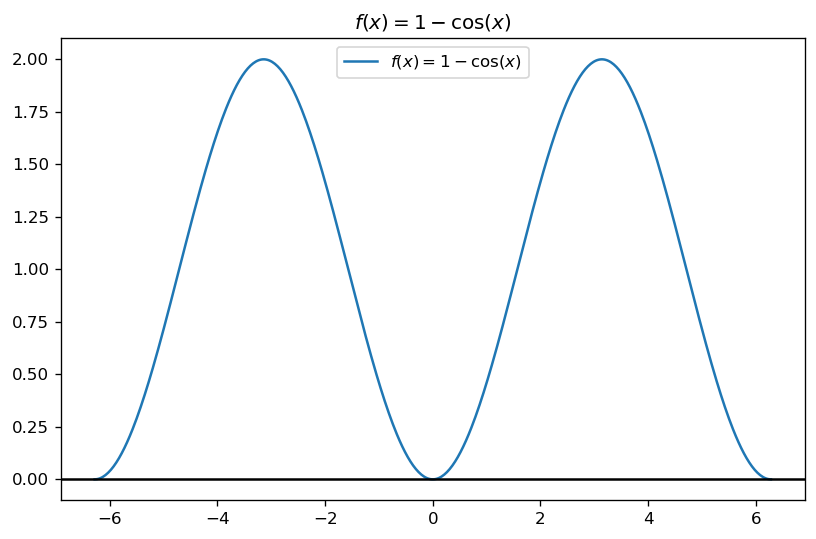

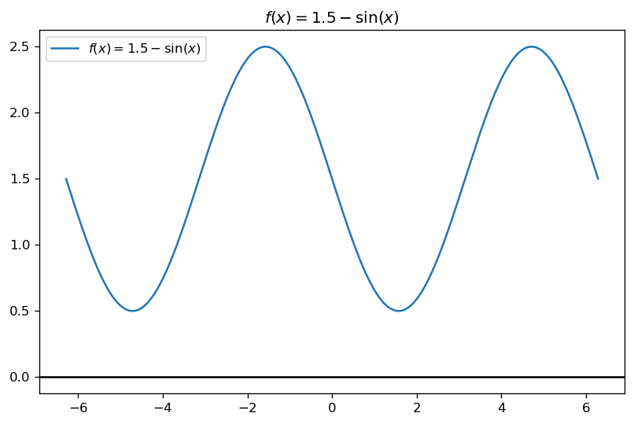

```python
x = np.linspace(-1.5, 1.5, 500)
y = (1 - x**2) * x
plt.figure(figsize=(8,5))
plt.plot(x, y, label=r'$f(x) = (1 - x^2) x$')
plt.axhline(0, color='black')
plt.title(r'$f(x) = (1 - x^2) x$')
plt.legend()
plt.show()


x = np.linspace(-2*np.pi, 2*np.pi, 500)
y = -np.sin(x)
plt.figure(figsize=(8,5))
plt.plot(x, y, label=r'$f(x) = -\sin(x)$')
plt.axhline(0, color='black')
plt.title(r'$f(x) = -\sin(x)$')
plt.legend()
plt.show()


x = np.linspace(-2*np.pi, 2*np.pi, 500)
y = 1 - np.cos(x)
plt.figure(figsize=(8,5))
plt.plot(x, y, label=r'$f(x) = 1 - \cos(x)$')
plt.axhline(0, color='black')
plt.title(r'$f(x) = 1 - \cos(x)$')
plt.legend()
plt.show()


x = np.linspace(-2*np.pi, 2*np.pi, 500)
y = 1.5 - np.sin(x)
plt.figure(figsize=(8,5))
plt.plot(x, y, label=r'$f(x) = 1.5 - \sin(x)$')
plt.axhline(0, color='black')
plt.title(r'$f(x) = 1.5 - \sin(x)$')
plt.legend()
plt.show()
```

### 2)

En se basant sur les graphes précédents, donner dans chaque cas le sens de variation et la limite quand $t\to +\infty$ de la solution de l'équation $$\begin{cases} \dot{x}(t)=f(x(t))\\ x(0)=x^{init} \end{cases}$$

- $f(x)=(1-x^2)x$, $x^{init}=0$.
- $f(x)=(1-x^2)x$, $x^{init}=0.5$.
- $f(x)=(1-x^2)x$, $x^{init}=1.5$.
- $f(x)=-\sin(x)$, $x^{init}=\pi/2$.
- $f(x)=1-\cos(x)$, $x^{init}=0$.
- $f(x)=1-\cos(x)$, $x^{init}=\pi/2$.
- $f(x)=1.5-\sin(x)$, $x^{init}=\pi/2$.

## Exercice 2 - Méthode d'Euler explicite

On considère l'équation $$\dot{x}(t)=f(t,x(t)),\ x(0)=1.$$ où $f(t,x)=-x+\sin(t)$, et on cherche à approcher la solution $t\mapsto x(t)$ sur l'intervalle de temps $t\in [0,T^{fin}]$ où $T^{fin}=10$. On rappelle la méthode d'Euler explicite vue en cours: on fixe un grand entier $N$ (le nombre de pas), et on pose

$$t_i=\frac{i T^{fin}}{N},\ \Delta t=\frac{T^{fin}}{N}$$ et $(x_i)_{i=0,...,N}$ est la suite (finie) définie par récurrence $$ \begin{cases} x_0=x^{init}\\ x_{i+1}=x_i+\Delta t\ f(t_i,x_i),\ i=0,1,2,...,N-1 \end{cases} $$

telle que $x_i$ est une ``bonne approximation'' de la valeur de la solution $t\mapsto x(t)$ au temps $t_i$.

### 1)

Écrire une fonction prenant en entrée un entier $N\in\N^*$, et qui renvoie les tableaux $T=[t_0,t_1,...,t_N],X=[x_0,x_1,...,x_N]$, construits par la méthode ci-dessus.

```python
#Réponse:

def euler_explicite(N):
    if N <= 0:
        return "N doit être strictement poditif"


    Tfin = 10
    x_init = 1
    delta_t = Tfin / N


    T = [i * delta_t for i in range(N + 1)]
    X = [0] * (N + 1)


    X[0] = x_init

    def f(t, x):
        return -x + np.sin(t)


    for i in range(N):
        X[i+1] = X[i] + delta_t * f(T[i], X[i])

    return T, X



print("T =", T)
print("X =", X)
```

[output not shown]

### 2)

Afficher le graphe de $(T,X)$ obtenu pour $N=10,15,20,50,100$. On représentera les cinq sur un même graphe.

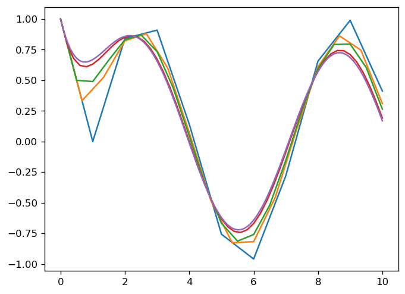

```python
#Réponse:
valeur_de_N = [10, 15, 20, 50, 100]
for N in valeur_de_N:
    T, X = euler_explicite(N)
    plt.plot(T, X, label=f'N={N}')
```

## Exercice 3 - Modèle de chute libre

Lorsqu'un parachutiste est en chute libre, un bon modèle de sa vitesse de chute $v(t)$ est l'équation $$\begin{cases} m\dot{v}(t)=mg-kv(t)^2,\text{ pour tout }t\geq 0\\ v(0)=0 \end{cases}$$ où $m>0$ est sa masse, $g>0$ est l'intensité de la pesanteur, et $k>0$ un coefficient de résistance de l'air. La distance parcourue après un temps $t$, notée $d(t)$, suit l'équation $$\begin{cases} d'(t)=v(t),\text{ pour tout }t\geq 0\\ d(0)=0 \end{cases}.$$

## 1)

Quel est le sens de variation et la limite (quand $t\to +\infty$) de la solution $t\mapsto v(t)$ ? On exprimera sa limite en fonction des paramètres $m,g,k$.

Réponse: v'(t)=g - (k/m)*v(t)^2 v(t) tend vers 0 on a v'(t)= g et plus v(t) agmente v'(t) diminue v(t) = sqrt((m*g)/k)

On donne les données expérimentales suivantes:

*Un parachutiste de $125.6kg$ (équipement compris) est lâché à une hauteur de $9570m$, il est en chute libre pendant $116s$ jusqu'à ce qu'il ouvre son parachute à une hauteur de $640m$. L'intensité de la pesanteur est supposée constante égale à $g=9.8m.s^{-2}$.*

Seule la quantité $k$ est inconnue, pour la trouver on va simuler la chute libre par une méthode d'Euler explicite pour différentes valeurs du paramètre $k$, calculer la distance parcourue en $116s$, et adapter $k$ pour la faire correspondre à la distance mesurée dans l'expérience.

### 2)

Quelle est sa vitesse moyenne pendant la chute libre ? En déduire un ordre de grandeur de la valeur de $k$ avec 3 chiffres significatifs.

Exemple : 0.945 ou 94.5 ont 3 chiffres significatifs, mais 0.048 et 4.8 n'en ont que 2.

### 3)

Écrire une fonction qui prend en entrée un nombre de pas (dans la méthode d'Euler) $N$, et un paramètre $k>0$, et renvoie la distance totale parcourue par le parachutiste dans sa chute libre, calculée par méthode d'Euler en $N$ pas avec un coefficient de resistance $k$.

```python
#Réponse:
def distance_parcourue(N, k):
    m = 125.6
    g = 9.8
    v0 = 0
    d0 = 0
    t0 = 0
    t_final = 116
    dt = (t_final - t0) / N

    v = v0
    d = d0

    for _ in range(N):
        dv = (m * g - k * v**2) / m * dt
        dd = v * dt
        v += dv
        d += dd

    return d
```

### 4)

Écrire une fonction qui prend une entrée les paramètres suivants: une fonction d'un paramètre réel $f(=f(x))$, deux nombres $a<b$ tels que $f(a)$ et $f(b)$ sont de signe opposés, $\epsilon>0$ un nombre, et qui renvoie en sortie un nombre $c$ tel que $a<c<b$ et $c$ est à distance $\epsilon$ d'une racine de $f$.

On pourra procéder par dichotomie grâce à l'algorithme suivant:

- 1 On pose $x\leftarrow a,y\leftarrow b$.
- 2 Si $f(x)f((x+y)/2)<0$, alors on pose $y\leftarrow(x+y)/2$, sinon on pose $x\leftarrow (x+y)/2$.
- 3 On répète l'étape $2$ tant que $|y-x|>\epsilon$.
- 4 On renvoie $(x+y)/2$.

```python
#Réponse:
def dichotomie(f, a, b, epsilon):
    x, y = a, b
    while abs(y - x) > epsilon:
        mid = (x + y) / 2
        if f(x) * f(mid) < 0:
            y = mid
        else:
            x = mid
    return (x + y) / 2
```

### 5)

Trouver une estimation de la valeur de $k$, et de la vitesse terminale du parachutiste. Il est assez facile d'obtenir une bonne approximation par ``tatonnement'', en testant plusieurs valeurs. Pour automatiser cela, on peut utiliser la méthode de dichotomie introduite à la question précédente. Utiliser $\varepsilon = 10^{-5}$.

```python
#Réponse:
def f(k):
    return distance_parcourue(1000, k) - (9570 - 640)

k_estime = dichotomie(f, 0.2, 0.3, 1e-5)
print("Valeur estimée de k :", k_estime)

v_lim = (125.6 * 9.8 / k_estime)**0.5
print("Vitesse terminale estimée :", v_lim, "m/s")
```

```
Valeur estimée de k : 0.2999969482421875
Vitesse terminale estimée : 64.05446956266277 m/s
```